# AD654_Assignment1_Yuqi Zheng

```python
%cd /Users/yuqizheng/Downloads/
```

```
/Users/yuqizheng/Downloads
```

```python
import pandas as pd
import numpy as np
import matplotlib.pyplot as plt
%matplotlib inline
import seaborn as sns
%cd /Users/yuqizheng/Downloads/
lob =  pd.read_csv("lobsterland.csv")
```

```
/Users/yuqizheng/Downloads
```

```python
lob.head()
```

|  | Date | Ad.Spend..Prior.Week | Promo1...Kids.Free.before.10am. | Promo2...Kids.Free.After.5pm. | Average.Gas.Cost..New.England | Day.of.Week | High.Temperature | Weather | Day.Passes.Sold | Water.Bottles.Sold | Lobster.Rolls.Sold | Ice.Cream.Cones.Sold | Refrigerator.Magnets.Sold | Larry.the.Lobster.Stuffed.Animals | TotalDailyRev |
| --- | --- | --- | --- | --- | --- | --- | --- | --- | --- | --- | --- | --- | --- | --- | --- |
| 0 | 27May2019 | 8500 | 1 | 0 | $2.61 | Monday | 61 | Sunny | 2727 | 2990 | 1927 | 2484 | 21 | 169 | 55509.868 |
| 1 | 28May2019 | 8500 | 0 | 0 | $2.67 | Tuesday | 67 | Overcast | 1696 | 1589 | 1927 | 1626 | 74 | 185 | 40709.758 |
| 2 | 29May2019 | 8500 | 0 | 0 | $2.75 | Wednesday | 61 | Sunny | 1175 | 1650 | 1721 | 1089 | 11 | 83 | 31696.150 |
| 3 | 30May2019 | 8500 | 0 | 0 | $3.14 | Thursday | 69 | Rainy | 850 | 1591 | 918 | 1358 | 24 | 87 | 22787.800 |
| 4 | 31May2019 | 8500 | 0 | 0 | $2.91 | Friday | 63 | Overcast | 2296 | 2779 | 1920 | 2039 | 21 | 202 | 49656.828 |

```python
lob.shape
```

```
(99, 15)
```

There are 99 rows and 15 coloums in lob dataset.

```python
lob.groupby('Day.of.Week')['TotalDailyRev'].describe()
```

| Day.of.Week | count | mean | std | min | 25% | 50% | 75% | max |
| --- | --- | --- | --- | --- | --- | --- | --- | --- |
| Friday | 14.0 | 61745.569143 | 14036.340176 | 43015.632 | 50227.5010 | 61338.139 | 67330.4860 | 91014.164 |
| Monday | 15.0 | 43059.519333 | 12317.141898 | 24283.258 | 37180.0600 | 42013.518 | 46007.0980 | 77921.194 |
| Saturday | 14.0 | 67453.798857 | 7131.350873 | 57535.676 | 63006.6165 | 65952.374 | 72994.2915 | 81434.298 |
| Sunday | 14.0 | 67971.901857 | 12167.223585 | 46122.592 | 63448.2350 | 65622.926 | 73242.1560 | 97555.016 |
| Thursday | 14.0 | 36854.192571 | 16317.853200 | 22787.800 | 27779.8830 | 31216.131 | 41580.8575 | 87893.128 |
| Tuesday | 14.0 | 27270.098000 | 6759.023229 | 17450.012 | 22414.4550 | 27731.748 | 31442.8465 | 40709.758 |
| Wednesday | 14.0 | 26676.568000 | 5509.486176 | 19296.560 | 23395.8050 | 25007.440 | 29703.8340 | 40391.728 |

```python
lob.drop('Refrigerator.Magnets.Sold',1, inplace=True)
```

```python
lob
```

|  | Date | Ad.Spend..Prior.Week | Promo1...Kids.Free.before.10am. | Promo2...Kids.Free.After.5pm. | Average.Gas.Cost..New.England | Day.of.Week | High.Temperature | Weather | Day.Passes.Sold | Water.Bottles.Sold | Lobster.Rolls.Sold | Ice.Cream.Cones.Sold | Larry.the.Lobster.Stuffed.Animals | TotalDailyRev |
| --- | --- | --- | --- | --- | --- | --- | --- | --- | --- | --- | --- | --- | --- | --- |
| 0 | 27May2019 | 8500 | 1 | 0 | $2.61 | Monday | 61 | Sunny | 2727 | 2990 | 1927 | 2484 | 169 | 55509.868 |
| 1 | 28May2019 | 8500 | 0 | 0 | $2.67 | Tuesday | 67 | Overcast | 1696 | 1589 | 1927 | 1626 | 185 | 40709.758 |
| 2 | 29May2019 | 8500 | 0 | 0 | $2.75 | Wednesday | 61 | Sunny | 1175 | 1650 | 1721 | 1089 | 83 | 31696.150 |
| 3 | 30May2019 | 8500 | 0 | 0 | $3.14 | Thursday | 69 | Rainy | 850 | 1591 | 918 | 1358 | 87 | 22787.800 |
| 4 | 31May2019 | 8500 | 0 | 0 | $2.91 | Friday | 63 | Overcast | 2296 | 2779 | 1920 | 2039 | 202 | 49656.828 |
| ... | ... | ... | ... | ... | ... | ... | ... | ... | ... | ... | ... | ... | ... | ... |
| 94 | 29August2019 | 6500 | 0 | 0 | $2.50 | Thursday | 75 | Sunny | 1508 | 1974 | 2317 | 1663 | 77 | 41960.048 |
| 95 | 30August2019 | 6500 | 0 | 0 | $2.30 | Friday | 79 | Overcast | 3999 | 4740 | 2957 | 4437 | 389 | 86131.970 |
| 96 | 31August2019 | 6500 | 0 | 0 | $2.35 | Saturday | 80 | Sunny | 3274 | 4579 | 1982 | 2874 | 320 | 65784.720 |
| 97 | 1September2019 | 6500 | 0 | 0 | $2.54 | Sunday | 76 | Overcast | 3068 | 3887 | 2397 | 2732 | 183 | 64981.580 |
| 98 | 2September2019 | 6500 | 0 | 1 | $2.62 | Monday | 72 | Sunny | 3411 | 4114 | 3093 | 3744 | 296 | 77921.194 |

99 rows × 14 columns

```python
lob.info()
```

```
<class 'pandas.core.frame.DataFrame'>
RangeIndex: 99 entries, 0 to 98
Data columns (total 14 columns):
Date                                 99 non-null object
Ad.Spend..Prior.Week                 99 non-null int64
Promo1...Kids.Free.before.10am.      99 non-null int64
Promo2...Kids.Free.After.5pm.        99 non-null int64
Average.Gas.Cost..New.England        99 non-null object
Day.of.Week                          99 non-null object
High.Temperature                     99 non-null int64
Weather                              99 non-null object
Day.Passes.Sold                      99 non-null int64
Water.Bottles.Sold                   99 non-null int64
Lobster.Rolls.Sold                   99 non-null int64
Ice.Cream.Cones.Sold                 99 non-null int64
Larry.the.Lobster.Stuffed.Animals    99 non-null int64
TotalDailyRev                        99 non-null float64
dtypes: float64(1), int64(9), object(4)
memory usage: 11.0+ KB
```

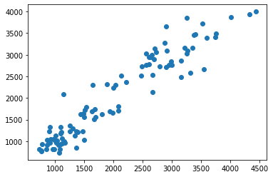

```python
from matplotlib import pyplot as plt
plt.scatter(lob['Ice.Cream.Cones.Sold'], lob['Day.Passes.Sold'])
```

Ice cream cones sold and day passes sold are closely related. Less day passes sold, less ice cream cone sold. In general, the relationship between ice cream cone sold and day passes sold are more closely within 1500. It is the same as my expectation because either ice cream cone sold and day passes sold are related to how many customers come every day. As we can see, the number of customers come to lobsterland are focused on around 1000.

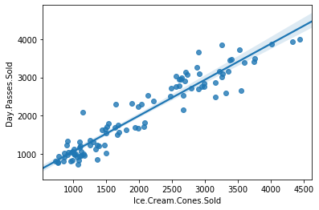

```python
sns.regplot(x=lob['Ice.Cream.Cones.Sold'], y=lob['Day.Passes.Sold'])
```

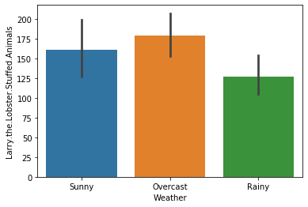

```python
sns.barplot(x='Weather',y='Larry.the.Lobster.Stuffed.Animals',data=lob)
```

Sales are lowest on rainy days and highest on overcast weather. This is the same as what I expected. In rainy days, people will reduce travel due to inconvenience caused by weather factors, and the sunny day makes people feel too hot, so the overcast weather is always the majority in our daily life.

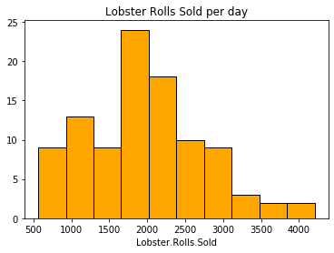

```python
plt.hist(lob['Lobster.Rolls.Sold'], color = "orange",ec='black')
plt.xlabel('Lobster.Rolls.Sold')
plt.title('Lobster Rolls Sold per day')
```

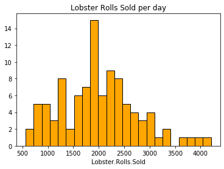

```python
plt.hist(lob['Lobster.Rolls.Sold'],23, color = "orange",ec='black')
plt.xlabel('Lobster.Rolls.Sold')
plt.title('Lobster Rolls Sold per day')
```

The second histogram has more bins and the y-axis become smaller than the first one. Also, the range of every bin become smaller than the first one. We also could see in the second plot, there is a blank in range 3500 (no day sold lobster rolls in range 3500) but in no any blank in the first one, which means the second one is more accurate than the first one.